# Part II - Factors affecting Borrower's Annual Percentage Rate (APR)

### by Ganiyat Issa-Onilu

## Investigation Overview

> The overall goal of this presentation is to explain the factors (i.e. prosper rating, income range and collateral) that affect borrower's annual loan payments. The following are key insights for this presentation:
> - Introduce the distribution of the borrower's APR (%) (dependent variable).
> - Explain the relationships between these factors and the dependent variable.

## Dataset Overview

> The dataset contains 113,937 loans with 81 variables on each loan, including loan amount, borrower rate (or interest rate), current loan status, borrower income, and many others. For the purpose of this project, 16 variables were selected for the explanatory analysis.

## Distribution of Borrower's APR

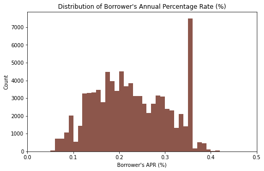

## Prosper Rating vs Borrower's APR

> The borrower's APR decreases with the increasing prosper rating. Borrowers with the best Prosper ratings have the lowest APR. It means that the Prosper rating has a negative association and strong effect on borrower APR.

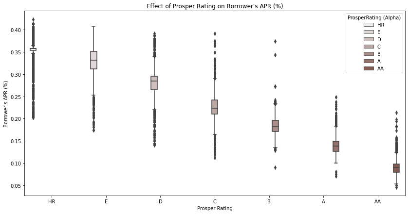

## Collateral vs Borrower's APR

> Borrowers that own homes to serve as collateral for loan requests tend to have lower annual percentage rate (APR) on average compared to those that do not own homes.

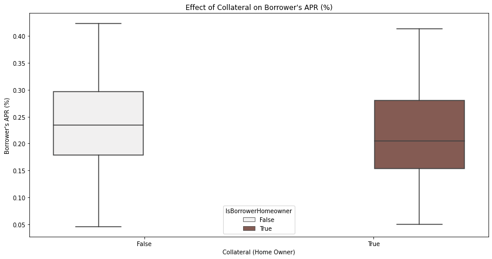

## Income Range vs Borrower's APR

> The borrower's APR decreases with higher income ranges. Borrowers with income range of 100000 dollars have the lowest APR while those with income range of $0 have the highest APR. In other words, Income Range has a strong effect on borrower APR.

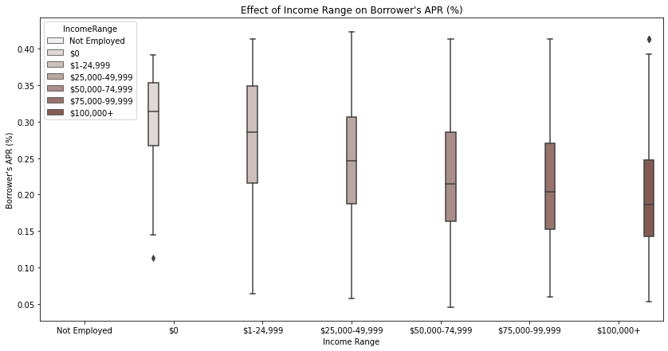

## Borrower's APR by Prosper Rating and Income Range

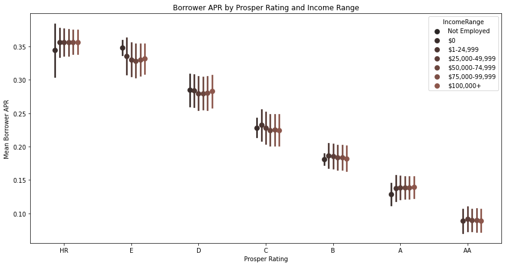